# Bivariate Inference_Week7+8

Author

Michael Cao

Published

February 24, 2025

**Hypothesis Test #1**

For the binary variable *pres20* from the 2022 GSS (“Did you vote for Biden”), grouped the variable *sex* (M/F).

Let’s ask: is there a difference in votes for Joe Biden between men and women?

$H_{0} : p_{male} - p_{female} = 0$

$H_{1} : p_{male} - p_{female} \neq 0$

For $\alpha = 0.01$

$\hat{p}_{male} = 0.561$

$\hat{p}_{female} = 0.668$

$\hat{p}_{male - female} = -0.106$

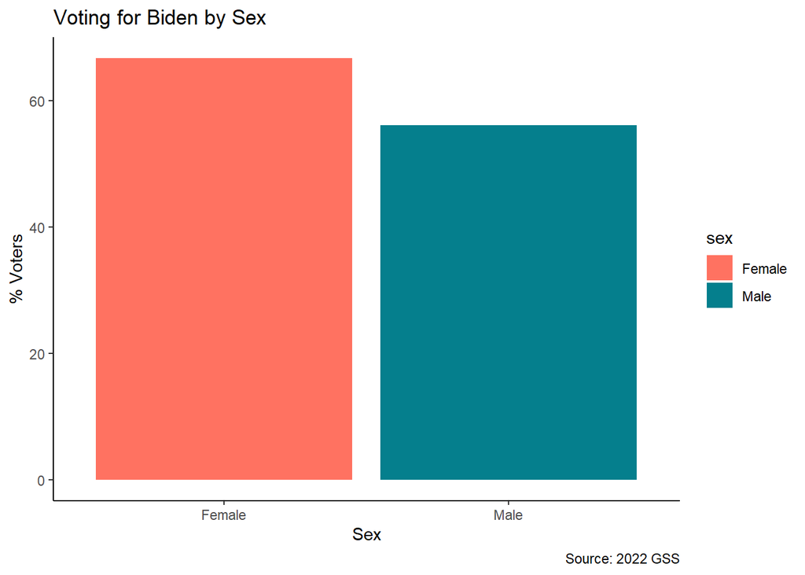

```r
z_stat1 <- abs((p1_pressex - p2_pressex) / sqrt(phat_total_pressex * (1 - phat_total_pressex) * (1 / n1_pressex + 1 / n2_pressex)))
round(z_stat1, 3) # Calculating the z-statistic
```

```
[1] 5.769
```

```r
p_stat1 <- 2 * (1 - pnorm(abs(z_stat1)))
p_stat1 # Calculating the p-value
```

```
[1] 7.952123e-09
```

Calculating a two-tailed p-value, our result is extremely small, which means we can reject the null hypothesis that there is no difference in men and women who voted Biden. It is beyond extreme that we would obtain our sample proportion difference given the null distribution. Translating this to a confidence interval, the 99% confidence interval for this sample would be $\{-0.154, -0.0591\}$. This interval does not include 0, so alternatively, we can use it to reject the null hypothesis.

**Hypothesis Test #2**

For the variable *life* (“Do you find life exciting or not”) from the 2022 GSS, grouped by *age* (Younger/Older).

Let’s ask: is there a difference in life excitement between the younger and the older?

$H_{0} : p_{younger} - p_{old} = 0$

$H_{1} : p_{younger} - p_{old} \neq 0$

For $\alpha = 0.01$

$\hat{p}_{younger} = 0.397$

$\hat{p}_{older} = 0.439$

$\hat{p}_{younger - older} = -0.043$

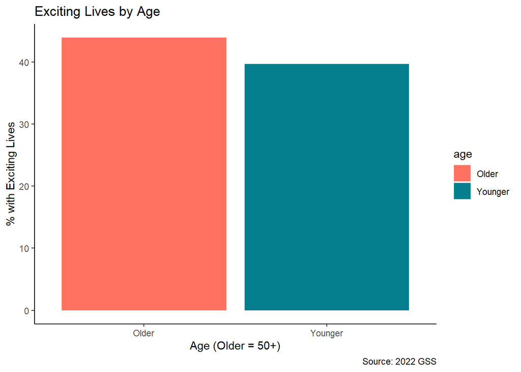

```r
z_stat2 <- abs((p1_lifeage - p2_lifeage) / sqrt(phat_total_lifeage * (1 - phat_total_lifeage) * (1 / n1_lifeage + 1 / n2_lifeage)))
round(z_stat2, 3) # Calculating the z-statistic
```

```
[1] 2.183
```

```r
p_stat2 <- 2 * (1 - pnorm(abs(z_stat2)))
p_stat2 # Calculating the p-value
```

```
[1] 0.02906237
```

Calculating a two-tailed p-value, our result is small but not small enough, which means we fail to reject the null hypothesis that there is no difference in life excitement among the younger and older. It “likely” here that we would obtain our sample proportion difference given the null distribution and our conservative alpha level. Translating this to a confidence interval, the 99% confidence interval for this sample would be $\{-0.09265, 0.008\}$. This interval does include 0, so alternatively, we can use it to fail to reject the null hypothesis.

**Hypothesis Test #3**

For the variable *nmbrkids* (“How many children have you ever had”) grouped by *degree* status (at least a BA/no BA).

Let’s ask: is there a difference in the number of children between those with and without a BA degree?

$H_{0} : \mu_{BA+} - \mu_{<BA} = 0$

$H_{1} : \mu_{BA+} - p_{<BA} \neq 0$

For $\alpha = 0.01$

$\bar{x}_{BA_+} = 1.887$

$\bar{x}_{<BA} = 2.14$

$\bar{x}_{BA_+ - <BA} = -0.253$

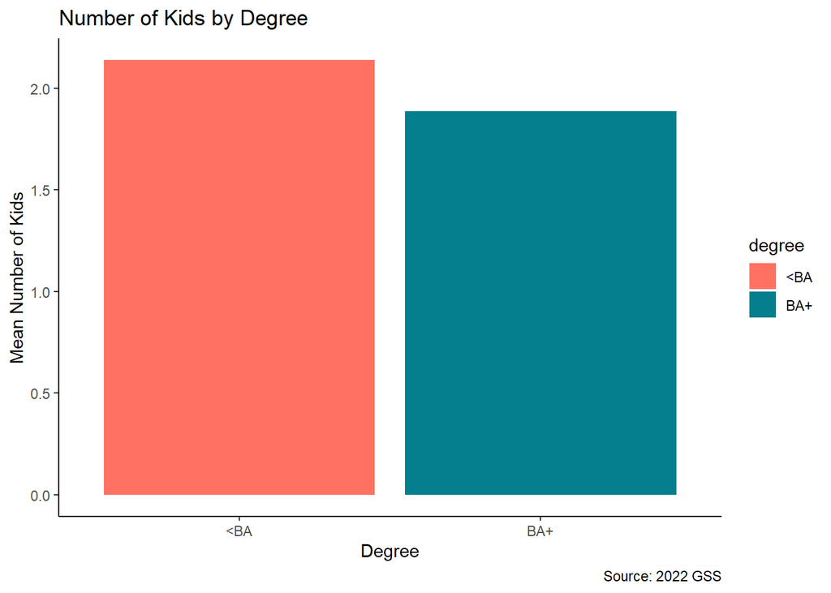

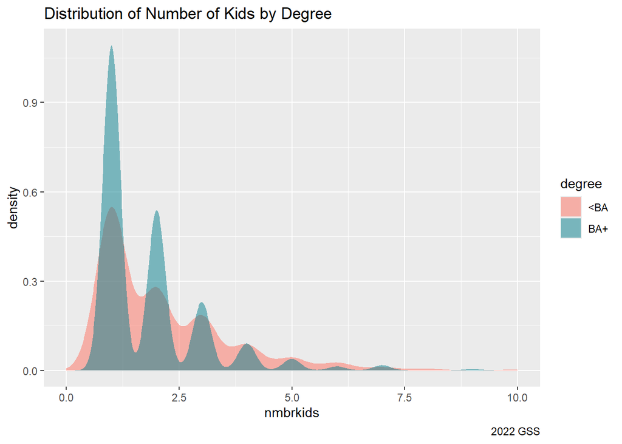

```r
z_stat3 <- abs((mean1_childcollege - mean2_childcollege) / se_diff_childcollege)
round(z_stat3, 3) # Calculating the z-statistic
```

```
[1] 3.352
```

```r
p_stat3 <- 2 * (1 - pnorm(abs(z_stat3)))
p_stat3 # Calculating the p-value
```

```
[1] 0.0008029039
```

Calculating a two-tailed p-value, our result is very small, which means we can reject the null hypothesis that there is no difference in the number of children among those with at least a BA degree and those without. It is highly unlikely that we would obtain our sample proportion difference given the null distribution. Translating this to a confidence interval, the 99% confidence interval for this sample would be $\{-0.446, -0.059\}$. This interval does not include 0, so alternatively, we can use it to reject the null hypothesis.

**Effect Size Calculations**

```r
data_frame3_other <- gss2022 |>
  select(nmbrkids, degree) |>
  drop_na() |>
  mutate(degree = if_else(degree >= 3, "BA+", "<BA")) |>
  mutate(degree = factor(degree, levels = c("BA+", "<BA")))

#Calculating Cohen's d using the "effectsize" package
cohens_d_childcollege <- cohens_d(nmbrkids ~ degree,
                                  data = data_frame3_other,
                                  pooled_sd = TRUE)
cohens_d_childcollege
```

```
Cohen's d |         95% CI
--------------------------
-0.15     | [-0.27, -0.04]

- Estimated using pooled SD.
```

```r
#Calculating Probability of Superiority using the "effectsize" package
p_superiority_childcollege <- p_superiority(nmbrkids ~ degree,
                                            data = data_frame3_other,
                                            parametric = FALSE)
p_superiority_childcollege
```

```
Pr(superiority) |       95% CI
------------------------------
0.44            | [0.41, 0.48]

- Non-parametric CLES
```

We obtain an Cohen’s d of $0.15$, which indicates there’s a difference of 0.15 pooled standard deviations between the BA+ and <BA groups, which is pretty small (Cohen’s d is negative to indicate directionality, the BA+ group has less kids). The probability of superiority is $0.44$, which indicates the likelihood that a randomly selected individual from the BA+ group has more kids than a randomly selected individual from the <BA group.

**Power Analysis, Effect Size**

```r
n1_childcollege
```

```
[1] 469
```

```r
n2_childcollege
```

```
[1] 859
```

```r
#using this function in the pwr package due to different sample sizes
pwr.t2n.test(n1 = n1_childcollege,
             n2 = n2_childcollege,
             d = NULL,
             sig.level = 0.01,
             power = 0.8,
             alternative = c("two.sided"))
```

```
     t test power calculation

             n1 = 469
             n2 = 859
              d = 0.1964606
      sig.level = 0.01
          power = 0.8
    alternative = two.sided
```

For $\alpha = 0.01$, our two sample sizes, and an (arbitrary) $power = 0.8$ (20% chance of false negatives), the smallest effect size we could reliably detect is $0.196$.

**Hypothesis Test #4**

For the variable *weight* grouped by *divorce* status (Divorced/Non-Divorced).

Let’s ask: is there a difference in weight between the divorced and non-divorced?

$H_0 : \mu_{divorced} - \mu_{non-divorced} = 0$

$H_0 : \mu_{divorced} - \mu_{non-divorced} \neq 0$

For $\alpha = 0.01$

$\bar{x}_{divorced} = 189.778$

$\bar{x}_{non-divorced} = 185.237$

$\bar{x}_{divorced - non-divorced} = 4.54$

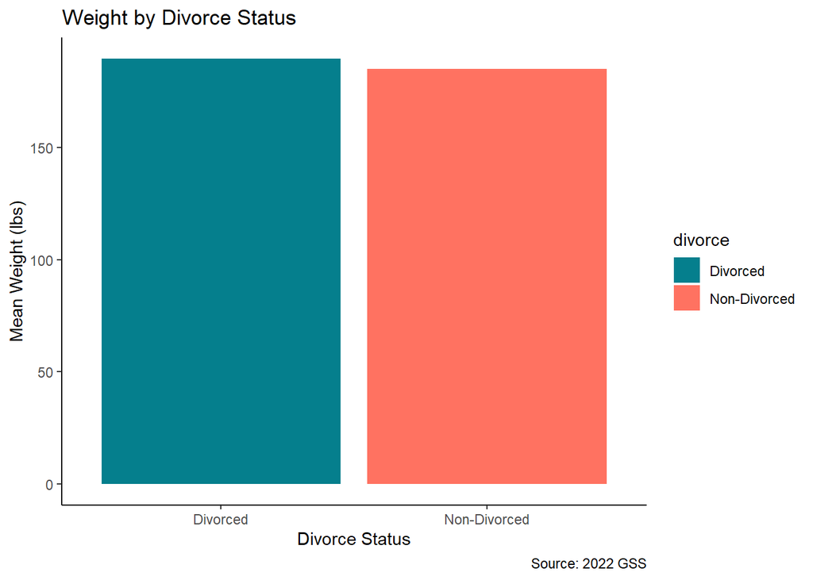

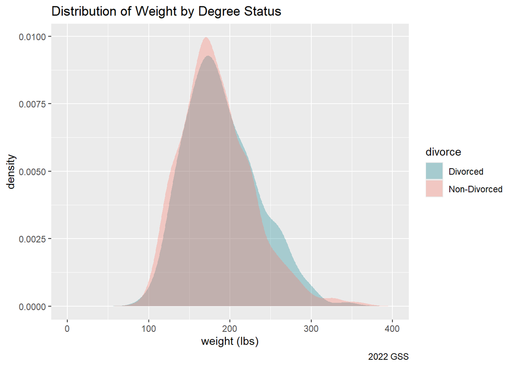

```r
z_stat4 <- abs((mean1_weightdiv - mean2_weightdiv) / se_diff_weightdiv)
round(z_stat4, 3) # Calculating the z-statistic
```

```
[1] 8.78
```

```r
p_stat4 <- 2 * (1 - pnorm(abs(z_stat4)))
p_stat4 # Calculating the p-value
```

```
[1] 0
```

**Effect Size Calculations**

```r
data_frame4_other <- gss2022 |>
  select(weight, divorce) |>
  drop_na() |>
  mutate(divorce = if_else(divorce == 1, "Divorced", "Non-Divorced"))

#Calculating Cohen's d using the "effectsize" package
cohens_d_weightdiv <- cohens_d(weight ~ divorce,
                               data = data_frame4_other,
                               pooled_sd = TRUE)
cohens_d_weightdiv
```

```
Cohen's d |        95% CI
-------------------------
0.09      | [-0.06, 0.24]

- Estimated using pooled SD.
```

```r
#Calculating Probability of Superiority using the "effectsize" package
p_superiority_weightdiv <- p_superiority(weight ~ divorce,
                                         data = data_frame4_other,
                                         parametric = FALSE)
p_superiority_weightdiv
```

```
Pr(superiority) |       95% CI
------------------------------
0.54            | [0.49, 0.58]

- Non-parametric CLES
```

We obtain an Cohen’s d of $0.09$, which indicates there’s a difference of 0.09 pooled standard deviations between the divorced and non-divorced groups (very small). The probability of superiority is $0.54$, which indicates the likelihood that a randomly selected individual from the divorced group weighs more than a randomly selected individual from the non-divorced group.

**Power Analysis, Effect Size**

```r
n1_weightdiv
```

```
[1] 216
```

```r
n2_weightdiv
```

```
[1] 838
```

```r
#using this function in the pwr package due to different sample sizes
pwr.t2n.test(n1 = n1_weightdiv,
             n2 = n2_weightdiv,
             d = NULL,
             sig.level = 0.01,
             power = 0.8,
             alternative = c("two.sided"))
```

```
     t test power calculation

             n1 = 216
             n2 = 838
              d = 0.2611913
      sig.level = 0.01
          power = 0.8
    alternative = two.sided
```

For $\alpha = 0.01$, our two sample sizes, and an (arbitrary) $power = 0.8$ (20% chance of false negatives), the smallest effect size we could reliably detect is $0.261$.

**Imaginary Experiment**

```r
pwr.t.test(n = NULL,
           d = 0.001,
           sig.level = 0.001,
           power = 0.999,
           alternative = c("two.sided"))
```

```
     Two-sample t test power calculation

              n = 81428175
              d = 0.001
      sig.level = 0.001
          power = 0.999
    alternative = two.sided

NOTE: n is number in *each* group
```

Just for fun, if we wanted to detect an effect size as small as 0.001 standard deviations, while minimizing the chance of both Type 1 and Type II error, we would need two groups with sample sizes of at least $n = 81428175$, or around 81 million people. Maybe some pissed off UNC fan really wanted to prove that the basketballs pumped at Cameron were *slightly* ever so lighter than the ones pumped at the Dean Dome.